# Exploratory Analysis

## Climate Change Affects

### Ryan Kang (kangryan@uw.edu), Annabelle Fallstrom(afalls@uw.edu), Tyler Nguyen (tyjn@uw.edu), Don Vo (donvo@uw.edu)

### May 17, 2024

Spring 2024

## Abstract

The primary objective is to rigorously analyze the effects of climate change across diverse facets and observe its impact on our planet’s various environmental domains–ecological, hydrological, oceanic, glaciological, and atmospheric systems. Through systematic data collection, we seek to highlight the specific impacts of climate change on the various environmental factors and explore their interrelations. Ultimately, the insights from our research are intended to inform and refine strategies for mitigation, adaptation, and response to the emergent challenges posed by our Earth’s devastating direction of climate change.

## Keywords

Climate Change, Global Warming, Carbon Footprint

## Proposal

1. Introduction

> Climate change has become a global epidemic, with human activities strongly impacting the Earth’s biodiversity, ecosystems, and, ultimately, the atmosphere. This causes tremendous concerns as these climate changes negatively influence other important natural resources such as our terrestrial, oceanic, glaciological, and hydrological ecosystems. As the effects of climate change multiply through the years to come, it is imperative to inform ourselves of its impacts and explore effective mitigation and adaptation strategies. This project aims to investigate the multifaceted effects of climate change on various environmental ecosystems and provide insights.

> Research Questions: - How has the frequency of intense weather events changed over the past 50 years?

```
- With this data, we could identify the severity of our climate change regarding natural disasters. Analyzing this data leads us to another question about climate temperature changes through the years.
```

- How have temperatures changed throughout the past 50 years in the North, West, South, and East sections of the world?
  - This data would help us understand possible hypotheses correlating temperature changes to other environmental factors, such as natural disasters.
- How has the ocean changed in the past 50 years in regards to acidity and sea levels?
  - When collecting climate change data, we would also need to dig deeper into the changes of our oceanic domain, to fully grasp how the acidity and sea levels correspond to the changes in our climate.
- What was the carbon footprint in the past 50 years?
  - Carbon footprint estimates the total emission volume of greenhouse gases, including carbon dioxide and other harmful chemicals. With this data, we could theoretically figure out how much carbon dioxide and other greenhouse gasses pose a harmful risk to our environment and the connection it makes to the everlasting effects of climate change.
2. Related Work

> As our topic, climate change is a major global issue; many others have also contributed to research involving what it could mean for the world as global temperatures continue to rise. Organizations such as NASA have already begun to address some of these consequences and dedicated pages on their websites specifically to raise awareness of what it could mean globally and for different regions across the United States. Here, we can see effects such as rising sea levels, hurricanes, droughts, heat waves, wildfires, flooding, and melting ice caps, all predicted to worsen if not addressed (1). Organizations have also been formed solely dedicated to the issue of climate change, like the Climate Impact Lab, which has done extensive research on the matter, lending to more in-depth insights. They provide similar data visualizations to what we hope to achieve on their impact map page, showing where global warming affects the most, and have pages dedicated to individual contributors and the consequences of climate change (2). They also use their data to predict how temperatures will look in the future depending on emission levels, emphasizing the effect humans can have on climate change. Fortunately, news of these changes is making its way to the public through news sources like BBC, which previously had an article on how climate change was impacting the melting of the arctic ice, detailing how it will ultimately affect sea levels and urging the public to take greater action (3).

Sources: - “Effects - NASA Science.” NASA, science.nasa.gov/climate-change/effects/. - “Impact Map.” Climate Impact Lab, 22 Dec. 2023, impactlab.org/map/. - Poynting, Mark. “Sea-Level Rise: West Antarctic Ice Shelf Melt ‘Unavoidable.’” BBC News, BBC, 23 Oct. 2023, www.bbc.com/news/science-environment-67171231.

3. The Dataset

> Data was found on PANGEA, an open-access library for georeferenced data from earth system research. (https://doi.pangaea.de/10.1594/PANGAEA.884141)  
> Here are all of the authors and contributors to this dataset, consisting mostly of scientists who research at universities or institutes:

```
1. Laboratoire des Sciences du Climat et de l’Environnement CEA CNRS UVSQ Institut Pierre-Simon Laplace, Gif-sur-Yvette, France

2. Cathy Nangini, Anna Peregon, Philippe Ciais, François-Marie Bréon & Yilong Wang

3. Mercator Research Institute on Global Commons and Climate Change, Berlin, Germany

4. Ulf Weddige & Felix Creutzig

5. Climate Research Division, Environment and Climate Change Canada, Toronto, Canada

6. Felix Vogel

7. Peking University Shenzhen Graduate School, Key Laboratory for Human and Environmental Science and Technology, Shenzhen, China

8. Jun Wang

9. CDP Worldwide, London, England

10. Simeran Bachra, Kyra Appleby & Sara Telahoun

11. Arizona State University, Arizona, USA

12. Kevin Gurney

13. National Institute for Environmental Studies, Tsukuba, Japan

14. Yoshiki Yamagata

15. Global Carbon Project, CSIRO Oceans and Atmosphere, Canberra, Australia

16. Josep G. Canadell

17. International Institute for Applied Systems Analysis, Laxenburg, Austria

18. Arnulf Grübler

19. Department of Energy, Environment and Climate Change, Asian Institute of Technology, Klong Luang, Pathumthani, Thailand

20. Shobhakar Dhakal

21. Sustainability Economics of Human Settlements, Technical University Berlin, Berlin, Germany

22. Felix Creutzig
```

> First, the researchers scoped the data from the Carbon Disclosure Project (CDP) about greenhouse gas emissions. This data was collected through online response systems, where people could report climate hazards. Governments disclosed emissions data. Then, they separated CO2 emissions from non-CO2 greenhouse gas emissions. Then, they integrated datasets about emissions from developing countries from the Carbon Climate Registry.

> Since cities are concentrations of population, energy use, and economic output, they are important focal points for investigating emission drivers and mitigation options. This prompts across-city comparative analyses of greenhouse gas emissions and energy use.

> There are 344 observation (rows) in the data.

> There are 180 features (columns) in the data.

> The authors declare that there are no competing interests for this dataset. We would like to consider the political and policy implications of the findings of this data and hold those responsible for the emissions accountable.

> The implications for technology, designers, and policymakers would be changes to combat climate change. Assuming we properly answered our research questions, we should see a trend in greenhouse gas emissions and rising carbon dioxide emissions. Coupled with the rising sea levels and ever-increasing heat, our data should show an increasing trend in carbon emissions over the years. This is most prominent in the big cities, where most of our data is from. Due to their massive scale, Big businesses and companies are the leading causes of rising levels of carbon dioxide in the atmosphere. Our data should expose this and shed more light on this topic. This should cause policymakers to make new policies to limit greenhouse gas emissions. This would also cause businesses and scientists to innovate and find new ways to limit emissions to comply with new regulations. Limiting major corporations’ greenhouse gas emissions will massively reduce the emissions in the atmosphere. Limitations & Challenges
5. Limitations & Challenges

> Some limitations to address with our project would be data on smaller countries, cities, and locations without the technology to record data properly. Our data isn’t fully complete; most of the data from our data set was self-reported rather than hand-collected. We have to count for slight inaccuracies in our data analysis. In our project proposal, we targeted many different effects of climate change. It could be challenging to manage and properly analyze all the data. Studying all the different side effects of climate change could make our proposal too broad and limit its effectiveness. Comparatively, if we only focused on one specific part of climate change, we could come up with a much deeper conclusion in that specific topic. However, that would make our proposal too narrow in scope. In our proposal, we must find the middle ground of covering all of our topics while fully answering our research questions.

Acknowledgements > - Data (https://doi.pangaea.de/10.1594/PANGAEA.884141) - Data visualizer (https://www.nature.com/articles/sdata2018280?WT.ec_id=SDATA-201901#Sec14)

### Table

```
## # A tibble: 187 × 9
## # Groups:   Emissions_Quality_Flag [5]
##    location          Population Reporting_year S1_GHG_emissions Year_of_emission
##    <chr>                  <dbl>          <dbl>            <dbl>            <dbl>
##  1 Faro, Portugal         64560           2016             128              2010
##  2 Ravenna, Italy        158784           2016           11115              2014
##  3 Salvador, Brazil     2920000           2016         3242166              2013
##  4 Belo Horizonte, …    2502557           2016         2804787              2013
##  5 Batangas, Philip…     329874           2016          344419              2010
##  6 Moita, Portugal        66029           2016           49910              2013
##  7 Bogotá, Colombia     8080734           2016        10679585.             2015
##  8 San Luis Potosí,…     824229           2016         1096123.             2015
##  9 La Paz, Bolivia       877363           2016         1152922.             2012
## 10 Sorocaba, Brazil      644919           2016          980290              2012
## # ℹ 177 more rows
## # ℹ 4 more variables: S2_GHG_emissions <dbl>, Total_emissions <dbl>,
## #   Emissions_Quality_Flag <chr>, Emissions_per_person <dbl>
```

Describe why you included the table and what information it reveals - The table allows you to more easily find the important information from the dataset. It filters out a majority of the na values and groups the data by their Emission Quality Flag rating and sorts by how much greenhouse gas a person emits. The original dataset had almost 200 columns and the column names were hard to read and understand. Renaming and reordering the columns allows the data to be much more legible and easier to understand.

### Chart 1

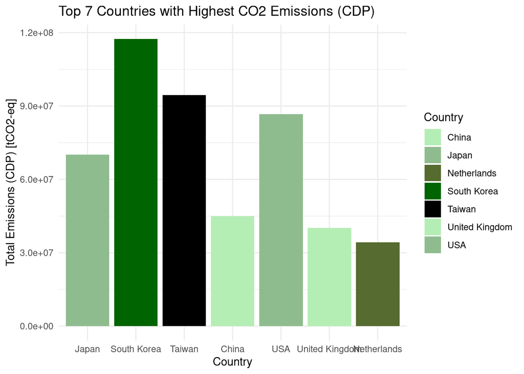

### Chart 2

[interactive chart not shown]

This map intends to show the relationship between where a city is geographically and its emmissions flag rating. This intends to show if where a city is has an impact on what kinds and how much emissions it produce.

### Chart 3

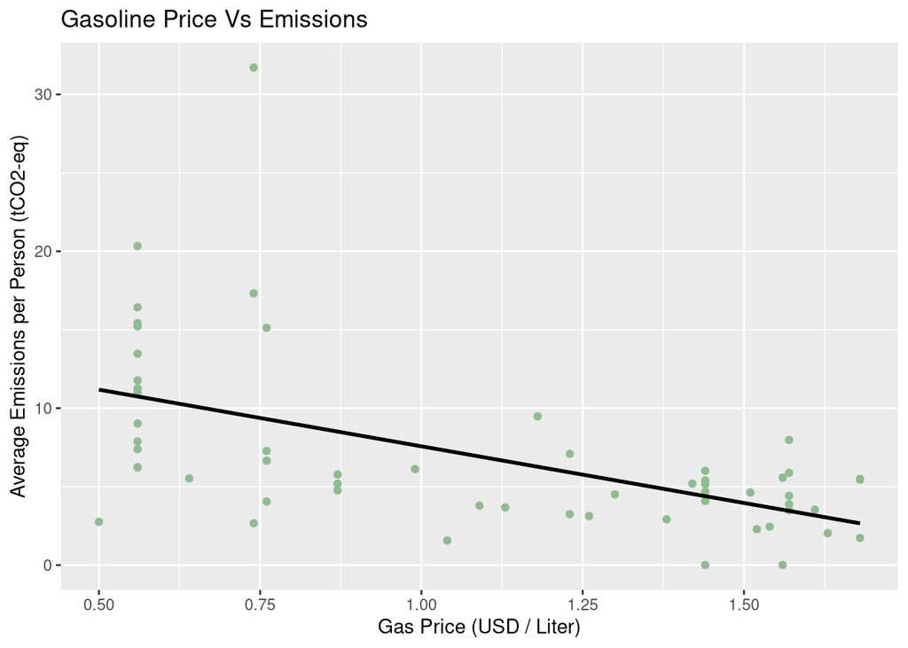

This scatter plot shows the relationship between the cost of gas and the average emissions per person of a city. It’s intent is to investigate if there is any correlation between the accessibility of fossil fuels to the general public and the amount of CO2 they release into the atmosphere in order to gauge if price management could be an effective control measure to help prevent climate change.